# 🧩 Criação e Documentação de Funções Personalizadas no R

As funções são fundamentais para tornar o código modular, organizado e legível. Mas além de criá-las, é importante documentar e seguir boas práticas — principalmente se você planeja criar pacotes ou scripts grandes.

**1️⃣ Estrutura Completa de uma Função**

```r
nome_funcao <- function(arg1, arg2 = valor_padrao, ...) {
  # Comentário explicando o que a função faz

  # Passo 1: (processamento)
  # Passo 2: (cálculo ou análise)

  resultado <- algo

  return(resultado)
}
```

**🔶 Exemplo prático**

```r
# Calcula média e desvio padrão de um vetor numérico
estatisticas <- function(x) {
  media <- mean(x)
  desvio <- sd(x)
  return(list(media = media, desvio = desvio))
}

valores <- c(10, 15, 20, 25)
estatisticas(valores)
```

```
$media
[1] 17.5

$desvio
[1] 6.454972
```

💡 Sempre que possível, retorne listas nomeadas, para facilitar o acesso aos resultados.

**2️⃣ Comentários e clareza do código**

Comentários (#) tornam o código mais legível.

Eles explicam o propósito, a lógica e os parâmetros da função.

```r
# Função que calcula o índice NDVI (vegetação)
calcular_ndvi <- function(banda_nir, banda_red) {
  # Fórmula: NDVI = (NIR - RED) / (NIR + RED)
  ndvi <- (banda_nir - banda_red) / (banda_nir + banda_red)
  return(ndvi)
}
```

💬 Comentários curtos e claros ajudam quem for ler seu código depois — inclusive você mesmo.

**3️⃣ Adicionando documentação estilo “help”**

Você pode criar uma documentação embutida, parecida com o ?mean do R.

Usa-se o padrão roxygen2 (mesmo que você não esteja criando pacotes).

```r
#' Calcula a média e o desvio padrão de um vetor numérico
#'
#' Esta função recebe um vetor numérico e retorna a média e o desvio padrão.
#'
#' @param x Vetor numérico de entrada.
#' @return Uma lista contendo:
#' \item{media}{A média dos valores}
#' \item{desvio}{O desvio padrão dos valores}
#' @examples
#' estatisticas(c(1, 2, 3, 4, 5))
estatisticas <- function(x) {
  media <- mean(x)
  desvio <- sd(x)
  return(list(media = media, desvio = desvio))
}
```

💡 Isso é essencial se você quiser criar pacotes no R, pois a documentação será exibida com ?estatisticas.

**4️⃣ Boas práticas na criação de funções** | Boas práticas | Explicação | | —————————— | —————————————————— | | ✅ **Nomes descritivos** | Use verbos claros: `calcular_media()`, `gerar_mapa()`. | | ✅ **Argumentos nomeados** | Evite depender da ordem dos parâmetros. | | ✅ **Retornar objetos simples** | Vetor, data frame ou lista com nomes. | | ✅ **Verificação de erros** | Use `stop()` e `warning()` para alertar problemas. | | ✅ **Comentários curtos** | Explique blocos de código, não cada linha. | | ✅ **Evite variáveis globais** | Use apenas variáveis locais dentro da função. |

**5️⃣ Lidando com erros e avisos**

Funções bem feitas verificam se as entradas são válidas antes de continuar.

```r
# Função com verificação de erro
calcular_media_segura <- function(x) {
  if (!is.numeric(x)) {
    stop("Erro: o argumento deve ser numérico.")
  }
  return(mean(x))
}

calcular_media_segura(c(10, 20, 30))   # funciona
```

```
[1] 20
```

```r
calcular_media_segura("texto")         # gera erro amigável
```

```
Error in calcular_media_segura("texto") :
  Erro: o argumento deve ser numérico.
```

💡 stop() interrompe a execução com mensagem de erro; warning() apenas avisa o usuário e continua.

**6️⃣ Funções com argumentos flexíveis (…)**

O operador “…” permite passar argumentos extras para outras funções.

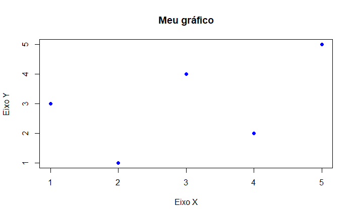

```r
# Função que faz gráficos personalizados
meu_plot <- function(x, y, ...) {
  plot(x, y, col = "blue", pch = 19, ...)
}

# Adicionando novos argumentos sem alterar a função
meu_plot(1:5, c(3,1,4,2,5), main = "Meu gráfico", xlab = "Eixo X", ylab = "Eixo Y")
```

💡 Isso é ótimo para funções genéricas e reutilizáveis.

**7️⃣ Funções dentro de pacotes**

Se você for evoluir para a criação de pacotes no R, cada função deve:

**Ter documentação roxygen2**

**Ficar em um arquivo .R separado**

**Ter exemplos de uso**

**Ter testes automáticos (testthat)**